# Proposal

Abdulrazzag M. Falah

April 3, 2018

## Final Project Proposal

In this project, I intend to replicate a study by Grilli et al. (2015) titled *Exploiting TIMSS and PIRLS combined data: multivariate multilevel modelling of student achievement*. This study looked into student achievement in Italy using a multivariate multilevel modeling. I intend to replicate the study on my home country, Yemen. However, there is a limitation to my replication. Yemen only took the Trends in International Mathematics and Science Study (TIMSS) test but not PIRLS. Accordingly, the analyses I will perform will only be on TIMSS. Additionally, the last time Yemen took the TIMSS test was in 2011 and that is the data I plan to use in this analysis. As shown below, there are 144 schools that participated in the study, but not all have appropriate sample size. some schools have less than 30 students that took the test. These schools will be dropped automatically.

**Depedent Variables:** Student achievement scores on **math** and **science**.

**Independent Variables:** Studnet demographical information, such as gender, family background, *wealth of surrounding area*.

**Group Identifier:** Schools

Below is an initial analysis of what the data looks like.

```r
#rm(list=ls())
list.of.packages <- c("foreign", "lme4", "sjstats", "ggplot2")
new.packages <- list.of.packages[!(list.of.packages %in% installed.packages()[,"Package"])]
if(length(new.packages)) install.packages(new.packages)
lapply(list.of.packages, require, character.only=TRUE)
```

```
## [[1]]
## [1] TRUE
##
## [[2]]
## [1] TRUE
##
## [[3]]
## [1] TRUE
##
## [[4]]
## [1] TRUE
```

```r
YemenData <- read.spss(file.choose(), to.data.frame = TRUE)
```

```
## re-encoding from UTF-8
```

```r
YemenData$IDSCHOOL <- as.factor(YemenData$IDSCHOOL)
YemenData$IDCLASS <- as.factor(YemenData$IDCLASS)
```

### Number of Schools and students within them

```r
freq.school <- as.data.frame(table(unique(YemenData)$IDSCHOOL))
length(levels(YemenData$IDSCHOOL))
```

```
## [1] 144
```

```r
length(levels(YemenData$IDCLASS))
```

```
## [1] 146
```

```r
head(freq.school)
```

```
##   Var1 Freq
## 1    1   90
## 2    2   80
## 3    3  124
## 4    4   92
## 5    5  102
## 6    6   48
```

```r
model1 <- lmer(ASMMAT02 ~ (1|IDSCHOOL), data = YemenData)
model2 <- lmer(ASMMAT02 ~ (1|IDCLASS), data = YemenData)

summary(model1)
```

```
## Linear mixed model fit by REML ['lmerMod']
## Formula: ASMMAT02 ~ (1 | IDSCHOOL)
##    Data: YemenData
##
## REML criterion at convergence: 120974
##
## Scaled residuals:
##     Min      1Q  Median      3Q     Max
## -2.9488 -0.7030 -0.0251  0.6592  3.9970
##
## Random effects:
##  Groups   Name        Variance Std.Dev.
##  IDSCHOOL (Intercept) 5232     72.33
##  Residual             7564     86.97
## Number of obs: 10234, groups:  IDSCHOOL, 144
##
## Fixed effects:
##             Estimate Std. Error t value
## (Intercept)  226.761      6.133   36.97
```

```r
summary(model2)
```

```
## Linear mixed model fit by REML ['lmerMod']
## Formula: ASMMAT02 ~ (1 | IDCLASS)
##    Data: YemenData
##
## REML criterion at convergence: 120970.1
##
## Scaled residuals:
##     Min      1Q  Median      3Q     Max
## -2.9499 -0.7026 -0.0258  0.6595  3.9986
##
## Random effects:
##  Groups   Name        Variance Std.Dev.
##  IDCLASS  (Intercept) 5216     72.22
##  Residual             7558     86.94
## Number of obs: 10234, groups:  IDCLASS, 146
##
## Fixed effects:
##             Estimate Std. Error t value
## (Intercept)  226.751      6.084   37.27
```

### Calculating the ICC for schools and classes

```r
icc(model1)
```

```
## Linear mixed model
##  Family: gaussian (identity)
## Formula: ASMMAT02 ~ (1 | IDSCHOOL)
##
##   ICC (IDSCHOOL): 0.408855
```

```r
icc(model2)
```

```
## Linear mixed model
##  Family: gaussian (identity)
## Formula: ASMMAT02 ~ (1 | IDCLASS)
##
##   ICC (IDCLASS): 0.408331
```

As we saw, the intraclass correlation coefficient is pretty high indicating multilevel data.

### Sample of schools on one plausible indicator of math acheivement.

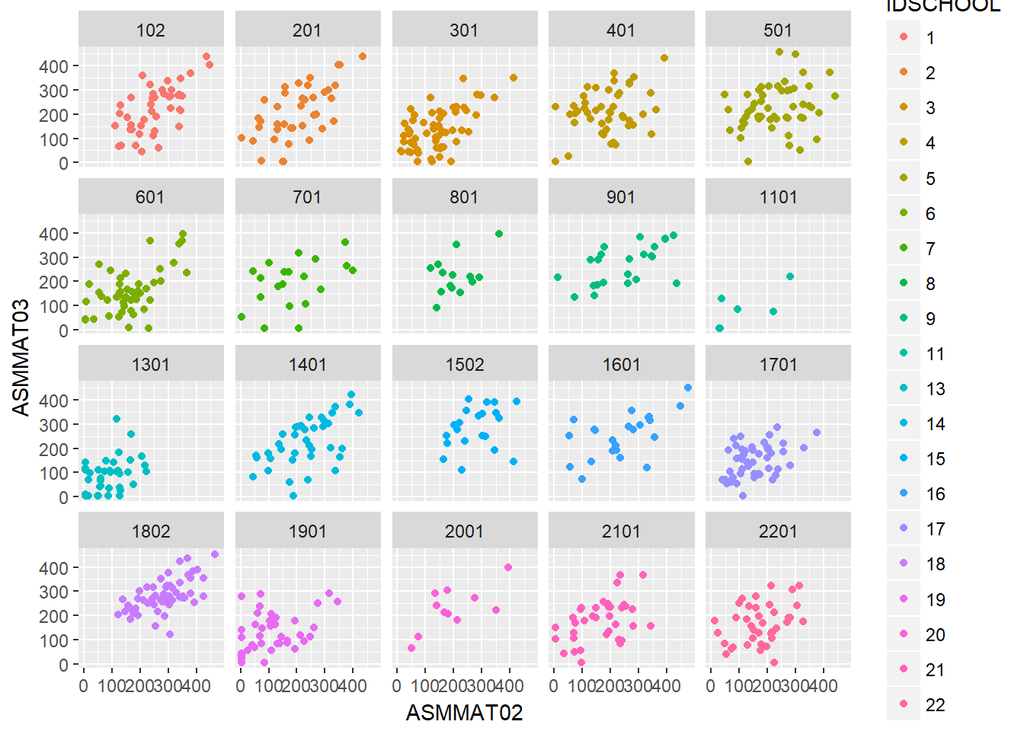

```r
ggplot(YemenData[as.numeric(YemenData$IDSCHOOL)<=20,], aes(x=ASMMAT02,y=ASMMAT03, color=IDSCHOOL)) +
  geom_point() +
  facet_wrap(~IDCLASS)
```